# Effect of Vitamin C and OJ on Tooth Growth

F. Alex Crofut

Saturday, April 23, 2016

## Synopsis

This analysis will explore the relationship between tooth growth and dose and supplement, both singly and in combination. First, the analysis will install necessary packages and the dataset. Second, the structure of the data will be examined, followed by an initial exploration of the data. the assumptions will be stated formally and confidence intervals will be employed to compare changes in dose and/or supplement type.

## Exploratory Data Analysis

### Required Packages

```r
if (!"datasets" %in% installed.packages()) install.packages("datasets")
library("datasets")
if (!"ggplot2" %in% installed.packages()) install.packages("ggplot2")
library("ggplot2")
if (!"gridExtra" %in% installed.packages()) install.packages("gridExtra")
library("gridExtra")
```

### Data Structure

The dataset ToothGrowth (from the datasets package) contains 60 observations on 3 variables:

```r
data(ToothGrowth)
str(ToothGrowth)
```

```
## 'data.frame':    60 obs. of  3 variables:
##  $ len : num  4.2 11.5 7.3 5.8 6.4 10 11.2 11.2 5.2 7 ...
##  $ supp: Factor w/ 2 levels "OJ","VC": 2 2 2 2 2 2 2 2 2 2 ...
##  $ dose: num  0.5 0.5 0.5 0.5 0.5 0.5 0.5 0.5 0.5 0.5 ...
```

```r
summary(ToothGrowth)
```

```
##       len        supp         dose
##  Min.   : 4.20   OJ:30   Min.   :0.500
##  1st Qu.:13.07   VC:30   1st Qu.:0.500
##  Median :19.25           Median :1.000
##  Mean   :18.81           Mean   :1.167
##  3rd Qu.:25.27           3rd Qu.:2.000
##  Max.   :33.90           Max.   :2.000
```

### Data Exploration

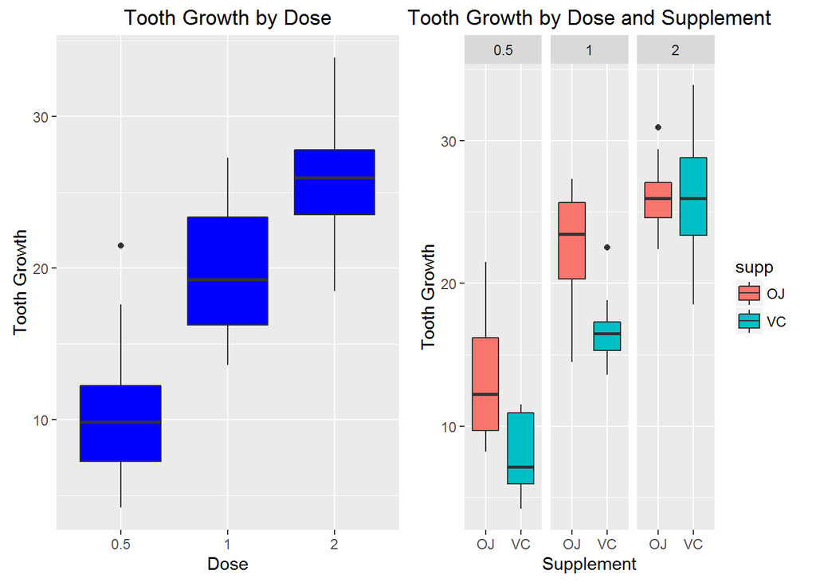

```r
p1 <- ggplot(aes(x = as.factor(dose), y = len), data = ToothGrowth) +
        geom_boxplot(fill = "blue") +
        labs(x = "Dose", y = "Tooth Growth") +
        ggtitle("Tooth Growth by Dose")
p2 <- ggplot(aes(x = supp, y = len), data = ToothGrowth) +
        geom_boxplot(aes(fill = supp)) + facet_wrap(~ dose) +
        labs(x = "Supplement", y = "Tooth Growth") +
        ggtitle("Tooth Growth by Dose and Supplement")
grid.arrange(p1, p2, ncol=2)
```

From the first boxplot, it appears that dose is indeed correlated with tooth growth. Furthermore, the second boxplot appears to show that the supplement choice has an effect at the two lower doses, but not at a dose of 2.0mg.

## Key Assumptions

In order to perform the following hypothesis tests, the following assumptions need to be made:

- Population is independent an didentically distributed
- Data is not paired
- Measurement error is accounted for by significant digits
- The study was double blind
- A 95% confidence is sufficient to determine significance in this case

## Hypothesis Tests

### Dose as only Determinant

```r
d1 <- subset(ToothGrowth, dose %in% c(0.5, 1.0))
d2 <- subset(ToothGrowth, dose %in% c(0.5, 2.0))
d3 <- subset(ToothGrowth, dose %in% c(1.0, 2.0))
t1 <- t.test(len ~ dose, paired=FALSE, var.equal = FALSE, data = d1)
t2 <- t.test(len ~ dose, paired=FALSE, var.equal = FALSE, data = d2)
t3 <- t.test(len ~ dose, paired=FALSE, var.equal = FALSE, data = d3)
```

The confidence intervals:

- [-11.984, -6.276] for increasing dose from 0.5mg to 1.0mg
- [-18.156, -12.834] for increasing dose from 0.5mg to 2.0mg
- [-8.996, -3.734] for increasing dose from 1.0mg to 2.0mg

All allow rejection of the null hypothesis that dose has no effect on tooth growth.

### Supplement as only Determinant

```r
supp <- t.test(len ~ supp, paired = FALSE, var.equal = FALSE, data = ToothGrowth)
```

The confidence interval [-0.171, 7.571] means the null hypothesis that Tooth Length is not affected by supplement choice **cannot** be rejected.

### Supplement Type as a Factor within Dose Levels

```r
d4 <- subset(ToothGrowth, dose == 0.5)
d5 <- subset(ToothGrowth, dose == 1.0)
d6 <- subset(ToothGrowth, dose == 2.0)
t4 <- t.test(len ~ supp, paired = FALSE, var.equal = FALSE, data = d4)
t5 <- t.test(len ~ supp, paired = FALSE, var.equal = FALSE, data = d5)
t6 <- t.test(len ~ supp, paired = FALSE, var.equal = FALSE, data = d6)
```

## Conclusions

Given the key assumptions and the results of the t-tests, one can infer that increases in dose have a significant correlation to tooth growth, regardless of the choice in supplements. Furthermore, the choice of supplements impacts the effectiveness of doses 0.5mg and 1.0mg. However, for doses of 2.0mg, the choice of supplement is no longer a significant effect. Finally, there is no evidence that the choice of supplement alone has a significant correlation with tooth growth.